# PPOL 646 Final Project: SNAP / Food Stamp Recipients

Bill Radovich

5/17/2021

**1.)**

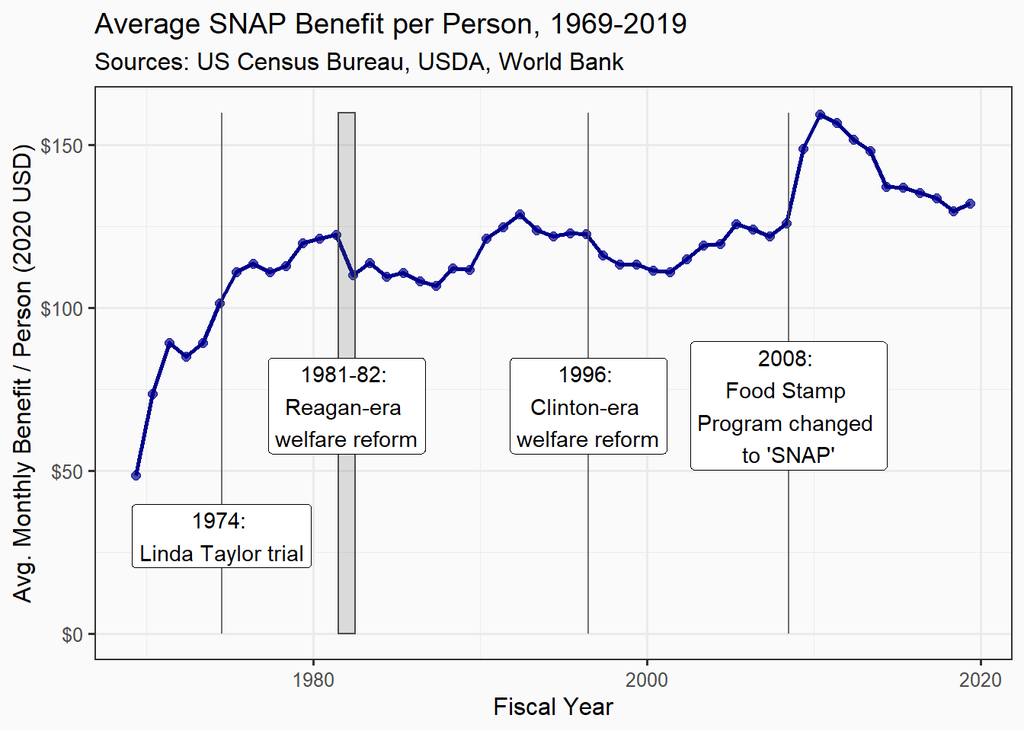

This graphic examines the lifetime of the Food Stamp Program / SNAP benefits granted to participants over the last 50 years. Significant events in the battle over welfare during this time period are highlighted. The oft-hurled stereotype of the “Welfare Queen” was born out of the publicised and nationally televised trial of Linda Taylor in 1974 - a political straw man that a common welfare recipient was a lazy black woman “gaming the system” for money - used by Ronald Reagan and anti-welfare advocates alike to pass new restrictions on welfare during the first years of his presidency - including Food Stamps. Following a hunger crisis in the mid-to-late-80s and a brief increase in benefits to recipients, welfare was reformed once again during the Clinton administration in 1996 - again heavily fueled by the “welfare queen” stereotype held by lawmakers. During the 2008-09 Global Recession, the Food Stamp program was heavily modified into the ‘SNAP’ program and replaced references to “stamps” or “coupon” with “card” or “EBT” to eradicate semantics that were previously used in racist attacks on the program and its recipients. SNAP funding has decreased in the past decade with a Republican-controlled congress influenced by the anti-welfare Tea Party movement and deficit hawks.  
**2.)**

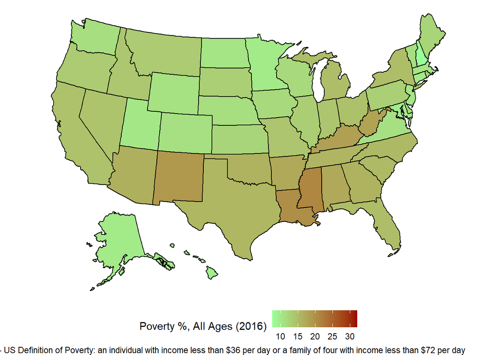

The distribution of poverty across the United States is shown in the map above. The light green highlighting states in the Great Plains, New England, the Mid-Atlantic, Alaska, and Hawaii indicate these regions generally have a lower poverty rate hovering around 8-12%. Darker orange-highlighted states in Appalachia and the Sun Belt have poverty rates of up to 20% - including states like Mississippi, New Mexico, West Virginia, and Kentucky. The West Coast and Midwest are somewhere in-between. The goal of this map was to gain insight into the actual poverty rates geographically and how these relate to the histories of each state and/or region of the country.  
**3.)**

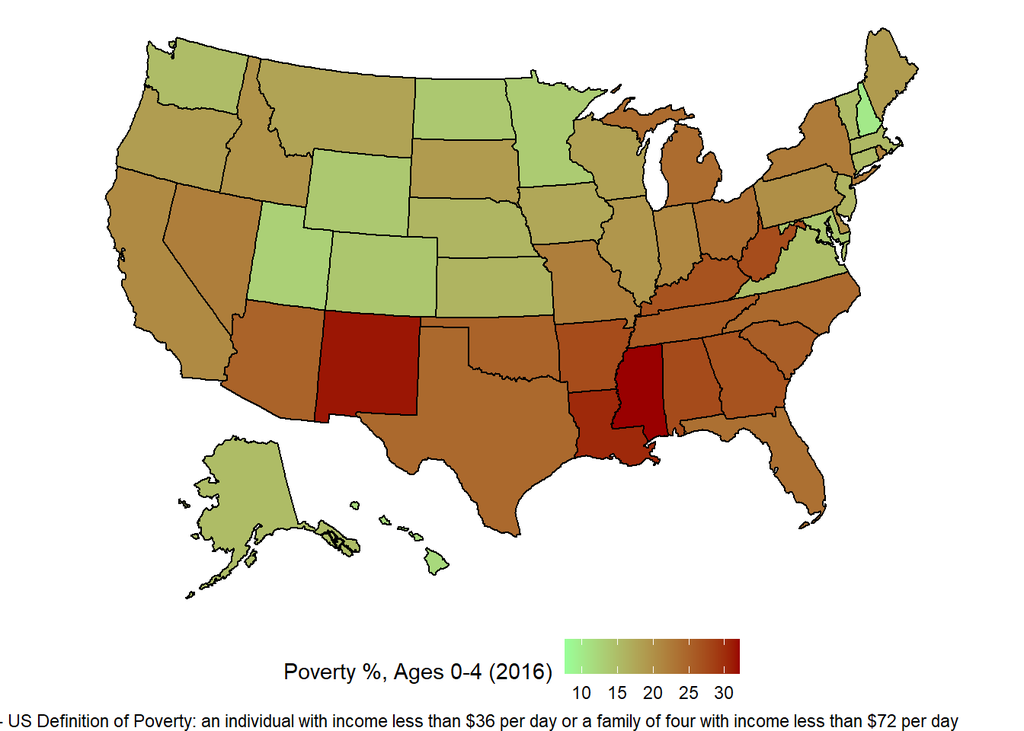

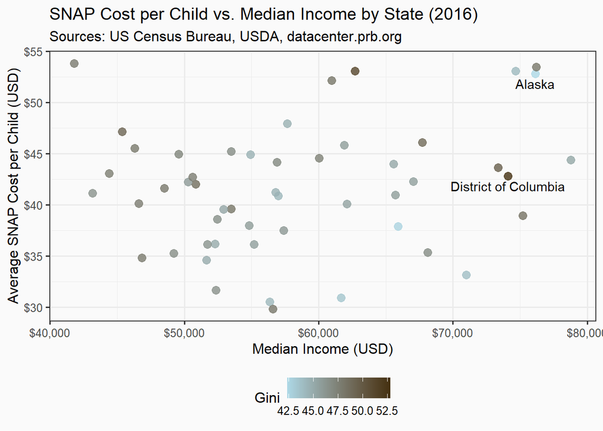

[figure not shown]

This interactive map aims to show the proportion of SNAP recipients whom are children, or women who are pregnant or postpartum. In most states, children make up more than half of recipients. Adult women make up around 20-25% of total SNAP recipients - including adult women who are pregnant or postpartum, who alone make up around 14%-20% depending on state. In Puerto Rico, 63.3% of recipients are children.  
**6.)**

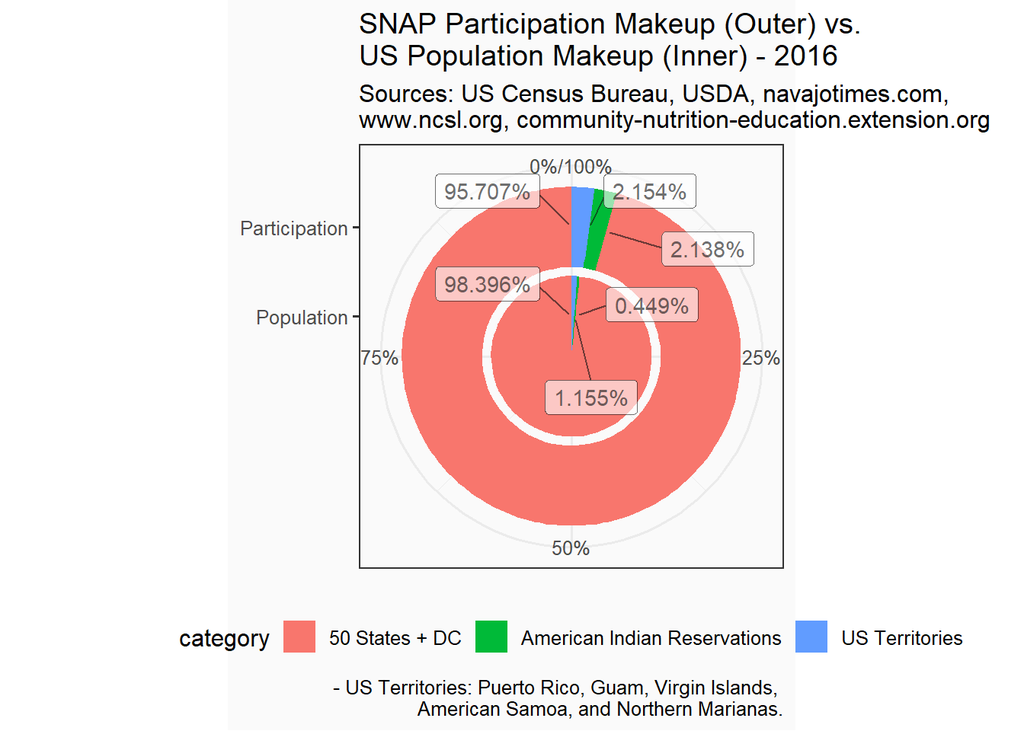

This donut chart highlights the massive discrepancy between the proportion of Americans outside the 50 states + DC in US Territories and American Indian Reservations and the much more significant proportion those Americans are on SNAP. American Indians living on Reservations, despite making up less than (an estimated) 0.449% of the US population in 2016, they made up an estimated 2.138% of all SNAP participants/recipients. Those living in the 5 US Territories - Guam, the Virgin Islands, American Samoa, Puerto Rico, and Northern Marianas - made up an estimated 2.154% of welfare recipients despite having 1.155% of the US population.  
**7.)**

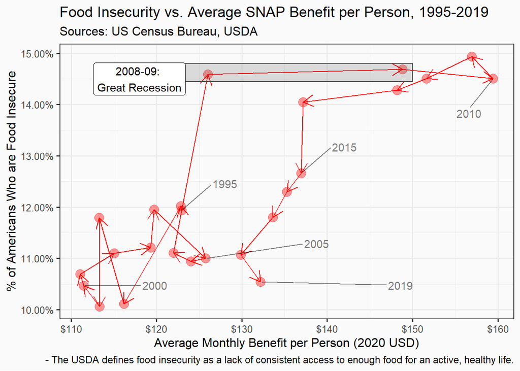

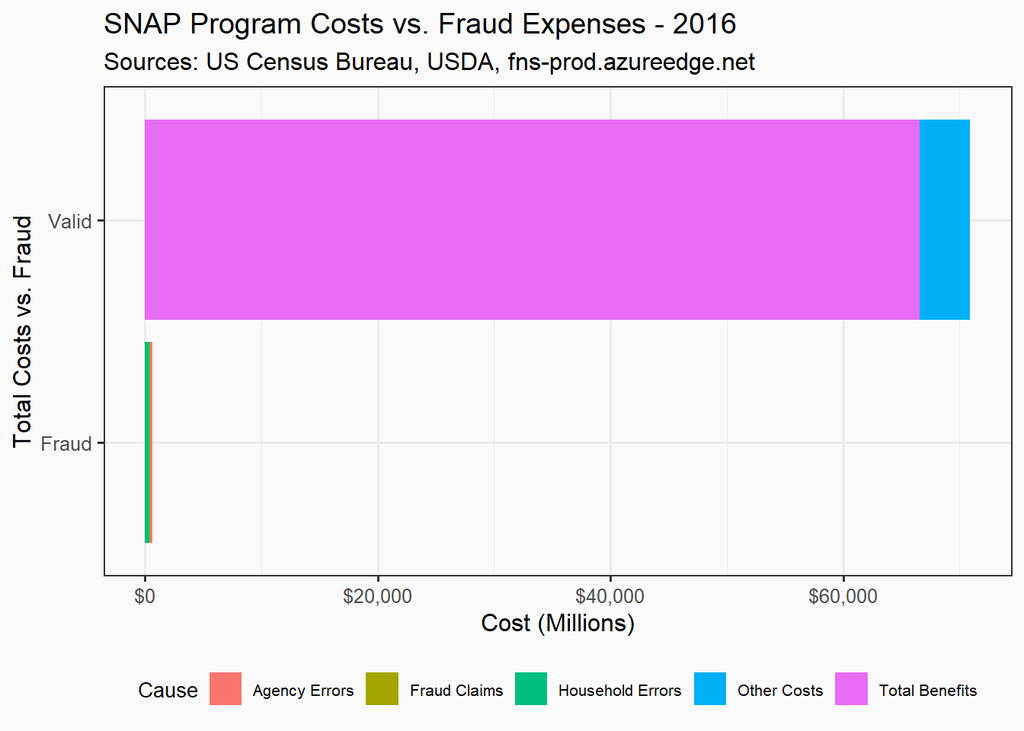

Despite anti-welfare advocates insisting on punishing welfare recipients due to the abusers and defrauders or imposing harsh restrictions that cut off recipients, fraud from participants makes up a tiny amount of the total money spent annually on SNAP - nearly all of which goes towards food or overhead costs. Household errors made up most fraud costs in 2016 at $424 million. Agency errors cost the program $188 million and fraudulent claims cost $73 million - compared to a total program expenditure of $70.9 billion.  
**9.)**

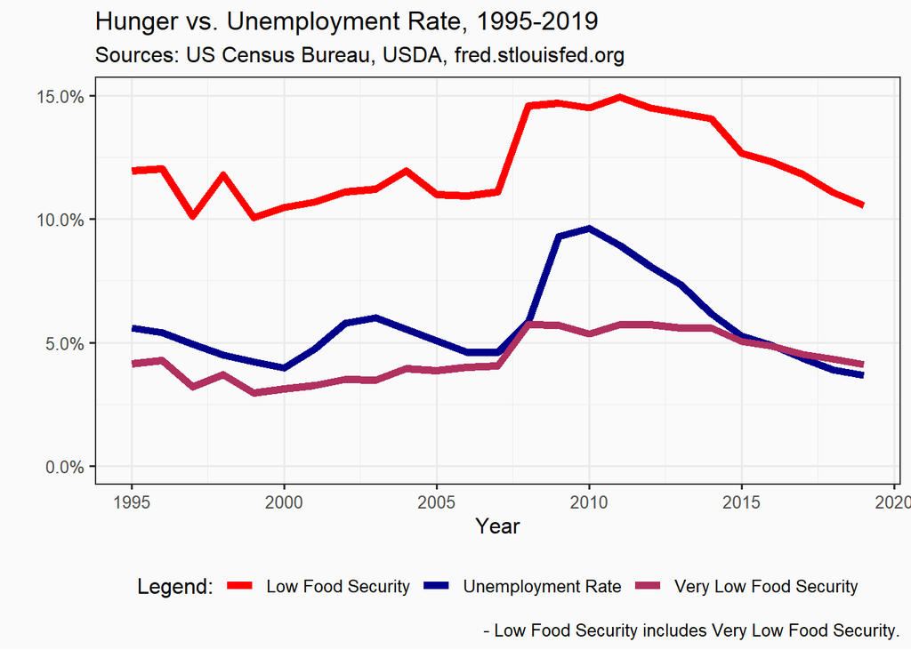

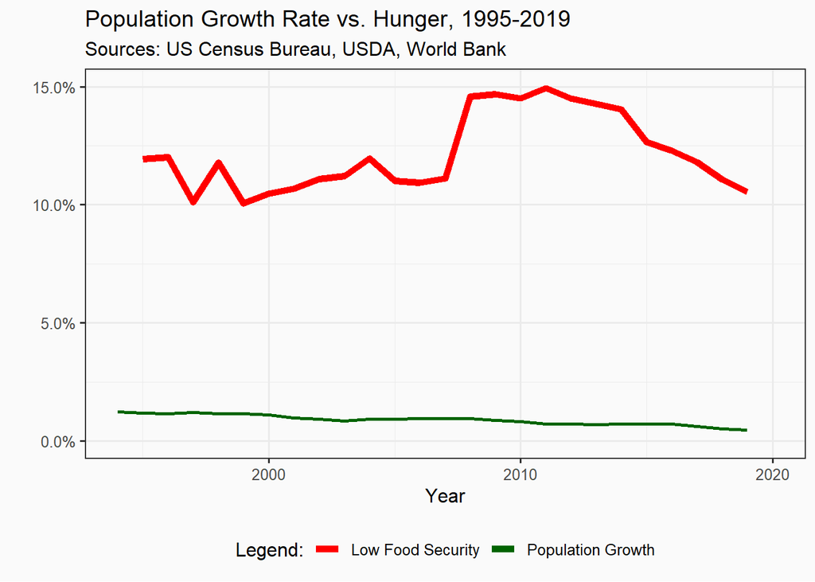

This line graph shows the trend for percentages of both low food security and population growth rate. Due to the relative economic hardship the United States has faced since the Great Recession, the resulting rise in hunger and its slow recovery, and the significant composition of children and their mothers, I expected to see a decline in the population growth rate over time if the decrease in birth rate was significant enough to drag it down. While there is no obvious correlation here, hunger and lack of appropriate nutrition to America’s mothers and children are a plausible cause for the steady decline in population growth since 1995. Factors such as higher levels of education and wider availability of birth control are also reasonable suggestions for this. In Today’s context, President Joe Biden has been posited as an “anti-Reagan” after laying out a massive jobs plan to a Joint Session in late April 2021 to fix the COVID-19 unemployment crisis, and attacking the Trickle Down Economics that have been the standard economic policy since Reagan himself. The effects of this spending will be noteworthy in determining if a return to Big Government can rapidly and measurably reduce economic hardship, and the suffering associated.

**Data sources:**  
1. https://www.kaggle.com/jpmiller/publicassistance  
2. https://fred.stlouisfed.org/graph/fredgraph.csv  
3. https://www2.census.gov/programs-surveys/popest/datasets/2010-2019/counties/totals/co-est2019-alldata.csv  
4. https://datacenter.prb.org/download/usdata/indicator/gini/csv  
5. http://navajotimes.com/news/2012/0112/012612census.php  
6. https://www.census.gov/newsroom/facts-for-features/2017/aian-month.html#:~:text=6.7%20million,the%20total%20population%20in%202016.  
7. https://www.ncsl.org/Portals/1/Documents/magazine/articles/2018/SL_0118-Stats.pdf  
8. https://community-nutrition-education.extension.org/wp-content/uploads/2020/09/MPR-Impact-Report_Print-Ready.pdf  
9. https://www.ers.usda.gov/media/10674/trends.xlsx  
10. https://fns-prod.azureedge.net/sites/default/files/snap/FY16-State-Activity-Report.pdf  
11. https://fred.stlouisfed.org/series/UNRATE  
12. https://data.worldbank.org/indicator/SP.POP.GROW

**Informational sources:**  
1. Borrelli, Christopher. “Reagan Used Her, the Country Hated Her. Decades Later, the Welfare Queen of Chicago Refuses to Go Away.” *Chicagotribune.com*, 10 June 2019, www.chicagotribune.com/entertainment/ct-ent-welfare-queen-josh-levin-0610-story.html.  
2. Bryant, Nick. “Opinion | Biden Isn’t FDR. He’s the Anti-Reagan.” *The Washington Post*, WP Company, 22 Apr. 2021, www.washingtonpost.com/opinions/2021/04/22/biden-isnt-fdr-hes-anti-reagan/.